# ch05_linear_models

## Tips and Hints

You must put the ch05_test_archive.pkl file inside the mavsim_python\mav_sim\unit_tests folder. This file can be found on canvas under Files->Unit_tests.

It is often easier to debug the code using the debugger and run the code in python instead of through the Jupyter file.

## Problem 1: Creating trim trajectory calculator

A trim state and input produce constant dynamic outputs. One way to produce the trim states and inputs is to solve an optimization problem that results in the desired trim state derivative. Consider the objective function defined as

$$ \min_{x_{trim}, \delta_{trim}} \bigl( f(x_{trim}, \delta_{trim}) - f_d \bigr)^T Q \bigl( f(x_{trim}, \delta_{trim}) - f_d \bigr) $$ where $f(x_{trim}, \delta_{trim})$ denotes the dynamics given the trim state and input, $f_d$ denotes the desired dynamics, and $Q \succeq 0$ is a diagonal matrix with weights along the diagonal. If possible, the optimization will produce trim states and inputs such that $f = f_d$.

Implement the following functions in `chap5\trim.py` using the cost and constraints discussed in lecture and described in the function docstrings.

- `velocity_constraint`
- `velocity_constraint_partial`
- `variable_bounds`
- `trim_objective_fun`

```python
# Note that this cell can be run separately to initialize for other cell blocks
import sys
import numpy as np
import os
import time
import warnings

# Suppress all warnings upfront
#warnings.filterwarnings('ignore')

# Configure Qt to use XCB (X11) instead of Wayland for better OpenGL support in Jupyter
# This provides native 3D visualization support
os.environ['QT_API'] = 'pyqt5'
os.environ['QT_QPA_PLATFORM'] = 'xcb'

# Add the parent directory to the Python path so mav_sim can be imported
sys.path.insert(0, os.path.abspath('..'))

from mav_sim.chap3.mav_dynamics import DynamicState
from mav_sim.chap4.run_sim import run_sim
from mav_sim.message_types.msg_sim_params import MsgSimParams
from mav_sim.message_types.msg_delta import MsgDelta
from mav_sim.tools.display_figures import display_data_view, display_mav_view
from mav_sim.chap2.mav_viewer import MavViewer
from mav_sim.chap3.data_viewer import DataViewer
from mav_sim.chap5.trim import compute_trim
from IPython.display import display # Used to display variables nicely in Jupyter
from mav_sim.chap3.mav_dynamics import DynamicState, derivatives
from mav_sim.chap3.mav_dynamics_euler import IND_EULER, derivatives_euler
from mav_sim.chap4.mav_dynamics import forces_moments, update_velocity_data
from mav_sim.tools.signals import Signals

# The viewers need to be initialized once due to restart issues with qtgraph
if 'mav_view' not in globals():
    print("Initializing mav_view")
    global mav_view
    mav_view = MavViewer()  # initialize the mav viewer
if 'data_view' not in globals():
    print("Initializing data_view")
    global data_view
    data_view = DataViewer()  # initialize view of data plots

# Initialize state values
sim_params = MsgSimParams(end_time=40.)
state = DynamicState()

# Functions used below
def run_sim_and_display(delta_fnc, init_state):
    global mav_view
    global data_view
    data_view.reset(sim_params.start_time)
    (mav_view, data_view) = run_sim(sim_params, delta_fnc, DynamicState(init_state), mav_view, data_view)
    display_data_view(data_view)
    display_mav_view(mav_view)
```

```
Initializing mav_view
Initializing data_view
```

## Problem 2 - Calculate Trim

Do the following:

1. Compute a trim state and input for $V_a = 25 \frac{m}{s}$, $\gamma = 0$, and $R=\infty$
2. Show that the resulting dynamics are close to the desired dynamics
3. Simulate the state and show that the trim values are achieved for a period before numerical errors enter the system

Keep in mind the following when comparing results:

- $\dot{p_n}$ and $\dot{p_e}$ are not important
- Your trim state dynamics will not be exact, but they should be close

```
trim_state =
```

```
array([[ 1.20935789e-13],
       [ 3.60667906e-15],
       [-1.00000000e+02],
       [ 2.49686227e+01],
       [ 0.00000000e+00],
       [ 1.25215085e+00],
       [ 9.99686174e-01],
       [-8.30798879e-05],
       [ 2.50508635e-02],
       [ 2.08187628e-06],
       [ 0.00000000e+00],
       [ 9.99999995e-13],
       [-7.27617743e-09]])
```

```
trim input =
elevator= -0.12504364980538027 aileron= 0.0018374628776430958 rudder= -0.0002928845826277178 throttle= 0.6767758538404245
Difference between actual and desired (Note that pn and pe are not important):
```

```
array([[ 2.50000000e+01],
       [ 2.08122418e-04],
       [ 7.34152083e-07],
       [ 6.30346587e-07],
       [-2.26592137e-07],
       [ 1.01214267e-07],
       [-3.64892630e-10],
       [-2.09387557e-13],
       [-7.28532124e-09],
       [-2.79901097e-06],
       [ 1.32289642e-06],
       [-1.27357172e-06]])
```

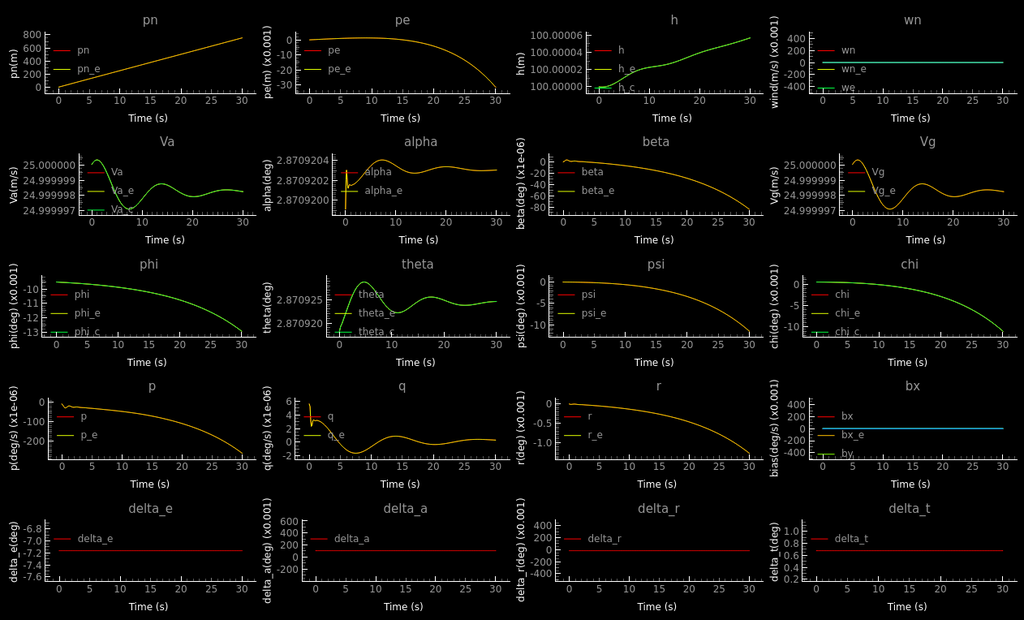

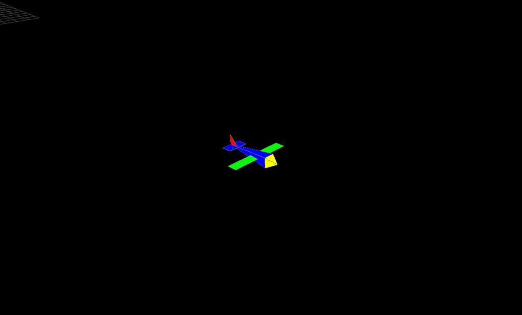

```python
# Create the trim state
Va_trim = 25.
gamma_trim = 0.
trim_state, trim_input = compute_trim(state.convert_to_numpy(), Va_trim, gamma_trim)

# Display the trim state and input
print('trim_state = ')
display(trim_state)
print('trim input = ')
trim_input.print()

# Convert quaternion state to Euler state for derivatives_euler
from mav_sim.chap3.mav_dynamics_euler import quat_state_to_euler_state
trim_state_euler = quat_state_to_euler_state(trim_state)

# Calculate the desired state dynamics
# pd_dot = -Va * sin(gamma)
# psi_dot = Va * cos(gamma) / R (R = infinity for straight line, so psi_dot = 0)
# All other state derivatives should be zero
desired_trim_state_dot = np.zeros((12, 1))
desired_trim_state_dot[IND_EULER.DOWN] = -Va_trim * np.sin(gamma_trim)
desired_trim_state_dot[IND_EULER.PSI] = Va_trim * np.cos(gamma_trim) / np.inf

# Calculate the actual state dynamics
# Note: update_velocity_data returns (Va, alpha, beta, wind_inertial_frame)
Va, alpha, beta, wind_inertial = update_velocity_data(trim_state)
forces_moments_result = forces_moments(trim_state, trim_input, Va, beta, alpha)
f = derivatives_euler(trim_state_euler, forces_moments_result)

# Display the difference
f_diff = f - desired_trim_state_dot
print("Difference between actual and desired (Note that pn and pe are not important):")
display(f_diff)

# Create a passthrough function for the trim input
pass_delta2 = lambda sim_time: trim_input
run_sim_and_display(pass_delta2, trim_state)
```

## Problem 3 - Trim Calculations

Repeat problem 2 with $V_a = 25 \frac{m}{s}$, $\gamma = 5$ degrees, and $R=\infty$

```
trim_state =
```

```
array([[ 1.04481457e-14],
       [ 1.85916470e-14],
       [-1.00000000e+02],
       [ 2.49695712e+01],
       [ 1.64505062e-21],
       [ 1.23309051e+00],
       [ 9.97668081e-01],
       [-2.69793085e-04],
       [ 6.82519348e-02],
       [ 1.84569402e-05],
       [ 1.27572737e-20],
       [ 1.00000000e-12],
       [-7.43615044e-09]])
```

```
trim input =
elevator= -0.12293089441191536 aileron= 0.005932661195054642 rudder= -0.0009457985237018074 throttle= 0.7737438667662584
Difference between actual and desired (Note that pn and pe are not important):
```

```
array([[ 2.49048675e+01],
       [ 6.66913725e-04],
       [ 4.84383809e-07],
       [-7.08669476e-07],
       [-4.29490849e-08],
       [-1.86412171e-07],
       [-1.02221993e-09],
       [-3.02182235e-12],
       [-7.50608145e-09],
       [-9.99786316e-07],
       [ 2.91035632e-07],
       [ 2.42266716e-07]])
```

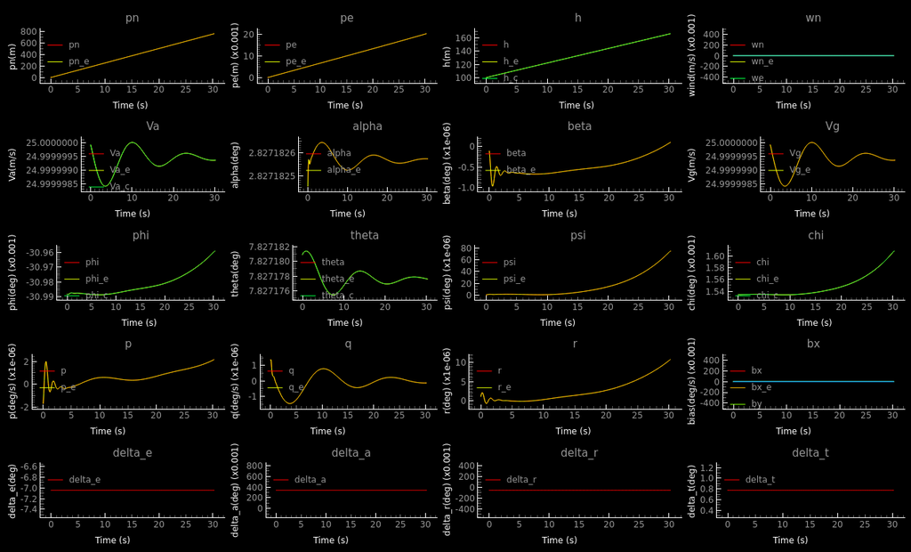

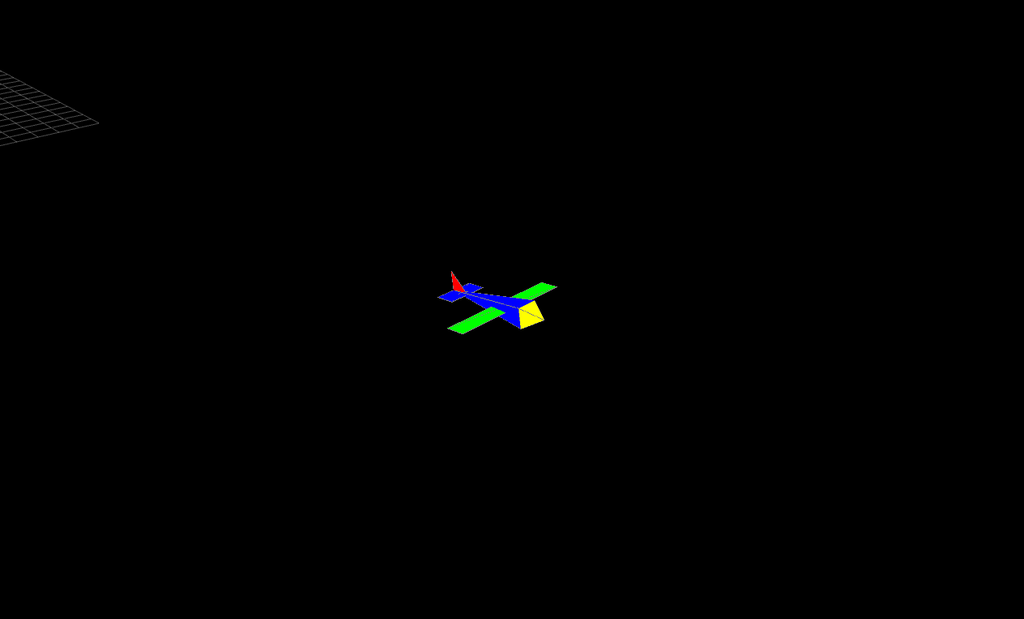

```python
# Create the trim state
Va_trim = 25.
gamma_trim = 5. * np.pi / 180.  # Convert degrees to radians
trim_state, trim_input = compute_trim(state.convert_to_numpy(), Va_trim, gamma_trim)

# Display the trim state and input
print('trim_state = ')
display(trim_state)
print('trim input = ')
trim_input.print()

# Convert quaternion state to Euler state for derivatives_euler
trim_state_euler = quat_state_to_euler_state(trim_state)

# Calculate the desired state dynamics
desired_trim_state_dot = np.zeros((12, 1))
desired_trim_state_dot[IND_EULER.DOWN] = -Va_trim * np.sin(gamma_trim)
desired_trim_state_dot[IND_EULER.PSI] = Va_trim * np.cos(gamma_trim) / np.inf

# Calculate the actual state dynamics
Va, alpha, beta, wind_inertial = update_velocity_data(trim_state)
forces_moments_result = forces_moments(trim_state, trim_input, Va, beta, alpha)
f = derivatives_euler(trim_state_euler, forces_moments_result)

# Display the difference
f_diff = f - desired_trim_state_dot
print("Difference between actual and desired (Note that pn and pe are not important):")
display(f_diff)

# Create a passthrough function for the trim input
pass_delta3 = lambda sim_time: trim_input
run_sim_and_display(pass_delta3, trim_state)
```

## Problem 4 - Trim Calculations

Repeat problem 2 with $V_a = 30 \frac{m}{s}$, $\gamma = 3$ degrees, and $R=800 m$

```
trim_state =
```

```
array([[ 5.73100396e-13],
       [ 1.18455127e-15],
       [-1.00000000e+02],
       [ 2.99935589e+01],
       [ 0.00000000e+00],
       [ 6.21629603e-01],
       [ 9.97630301e-01],
       [ 5.83461094e-02],
       [ 3.64002953e-02],
       [-2.12886037e-03],
       [ 0.00000000e+00],
       [ 1.00000000e-12],
       [ 3.76053892e-02]])
```

```
trim input =
elevator= -0.04371385492577787 aileron= 0.0007294330351033833 rudder= -0.0026148990311327057 throttle= 0.8578555235768652
Difference between actual and desired (Note that pn and pe are not important):
```

```
array([[ 2.99587986e+01],
       [-7.24637828e-02],
       [ 3.11177315e-06],
       [-1.20935235e-06],
       [-1.76502136e-05],
       [ 9.89599955e-07],
       [ 2.72912186e-03],
       [-4.38368563e-03],
       [-2.00407926e-08],
       [-1.17758158e-06],
       [ 2.59311208e-07],
       [-2.74588514e-06]])
```

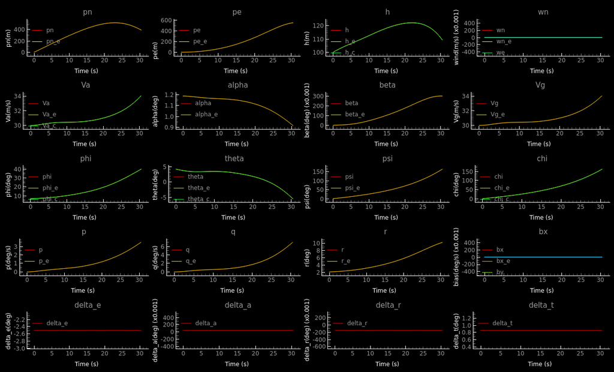

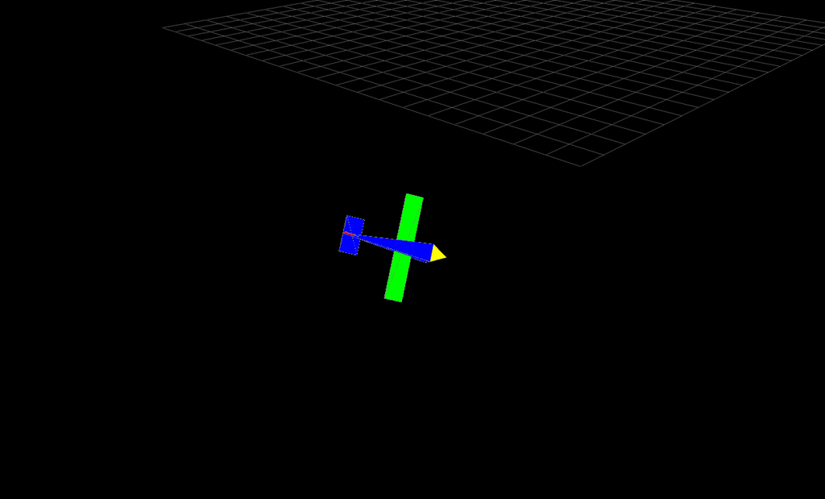

```python
# Create the trim state
Va_trim = 30.
gamma_trim = 3. * np.pi / 180.  # Convert degrees to radians
R = 800.  # radius in meters
trim_state, trim_input = compute_trim(state.convert_to_numpy(), Va_trim, gamma_trim, R)

# Display the trim state and input
print('trim_state = ')
display(trim_state)
print('trim input = ')
trim_input.print()

# Convert quaternion state to Euler state for derivatives_euler
trim_state_euler = quat_state_to_euler_state(trim_state)

# Calculate the desired state dynamics
desired_trim_state_dot = np.zeros((12, 1))
desired_trim_state_dot[IND_EULER.DOWN] = -Va_trim * np.sin(gamma_trim)
desired_trim_state_dot[IND_EULER.PSI] = Va_trim * np.cos(gamma_trim) / R

# Calculate the actual state dynamics
Va, alpha, beta, wind_inertial = update_velocity_data(trim_state)
forces_moments_result = forces_moments(trim_state, trim_input, Va, beta, alpha)
f = derivatives_euler(trim_state_euler, forces_moments_result)

# Display the difference
f_diff = f - desired_trim_state_dot
print("Difference between actual and desired (Note that pn and pe are not important):")
display(f_diff)

# Create a passthrough function for the trim input
pass_delta4 = lambda sim_time: trim_input
run_sim_and_display(pass_delta4, trim_state)
```

## Problem 5 - Evaluate Eigenvalues of Longitudinal System

The `compute_ss_model(...)` function inside `chap5\compute_models.py` provides a numerical approximation for the models described in (5.44) and (5.51).

For the trim trajectory corresponding to $V_a = 25 \frac{m}{s}$ and $\gamma = 0$, do the following:

- Calculate the eigenvalues of $A_{lon}$ and $A_{lat}$
- Answer the questions below

```python
from mav_sim.chap5.compute_models import compute_ss_model

# Compute the trim state and input
Va_trim = 25.
gamma_trim = 0.
trim_state, trim_input = compute_trim(state.convert_to_numpy(), Va_trim, gamma_trim)

# Compute A_lon and A_lat
A_lon, B_lon, A_lat, B_lat = compute_ss_model(trim_state, trim_input)

# Compute the eigenvalues of A_lon
eigenvalues_lon = np.linalg.eigvals(A_lon)
print("Longitudinal System Eigenvalues:")
for i, eig in enumerate(eigenvalues_lon):
    if np.iscomplex(eig):
        print(f"  λ{i+1} = {eig.real:.4f} ± j{abs(eig.imag):.4f}")
    else:
        print(f"  λ{i+1} = {eig.real:.4f}")

# Compute the eigenvalues of A_lat
eigenvalues_lat = np.linalg.eigvals(A_lat)
print("\nLateral System Eigenvalues:")
for i, eig in enumerate(eigenvalues_lat):
    if np.iscomplex(eig):
        print(f"  λ{i+1} = {eig.real:.4f} ± j{abs(eig.imag):.4f}")
    else:
        print(f"  λ{i+1} = {eig.real:.4f}")
```

```
Longitudinal System Eigenvalues:
  λ1 = 0.0000
  λ2 = -4.8786 ± j9.8696
  λ3 = -4.8786 ± j9.8696
  λ4 = -0.1041 ± j0.4891
  λ5 = -0.1041 ± j0.4891

Lateral System Eigenvalues:
  λ1 = -22.4412
  λ2 = -1.1408 ± j4.6551
  λ3 = -1.1408 ± j4.6551
  λ4 = 0.0894
  λ5 = 0.0000
```

## Problem 6 - Phugoid mode

For the trim trajectory corresponding to $V_a = 25 \frac{m}{s}$ and $\gamma = 0$, use a doublet to excite the phugoid mode. Simulate the response. (Note that this problem is provided for you)

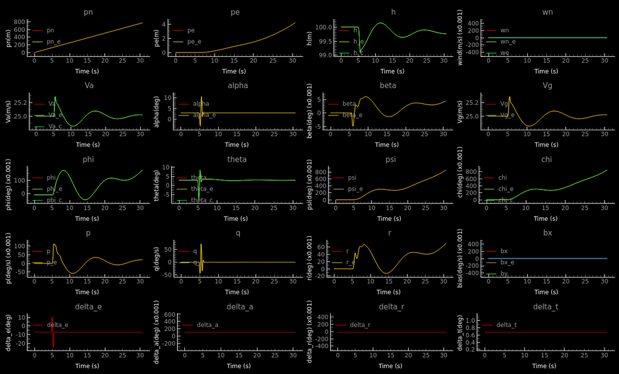

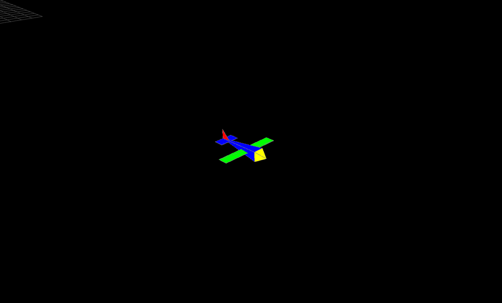

```python
# Create the trim state
Va_trim = 25.
gamma_trim = 0.
trim_state, trim_input = compute_trim(state.convert_to_numpy(), Va_trim, gamma_trim)

# Create an input signal
input_signal = Signals(amplitude=0.3,
                    duration=0.3,
                    start_time=5.0)

# Create a function for exciting the phugoid mode
def excite_phugoid(sim_time: float):
    # copy the trim command
    delta_cmd = MsgDelta()
    delta_cmd.copy(trim_input)

    # Excite the phugoid mode
    delta_cmd.elevator += input_signal.doublet(sim_time)
    return delta_cmd

# Run the command
run_sim_and_display(excite_phugoid, trim_state)
```

## Problem 7 - Roll and spiral divergence modes

For the trim trajectory corresponding to $V_a = 25 \frac{m}{s}$ and $\gamma = 0$, use a doublet to excite the roll and spiral divergence modes.

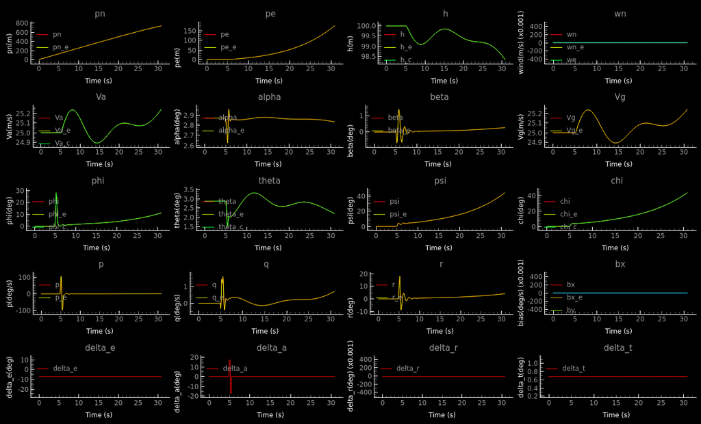

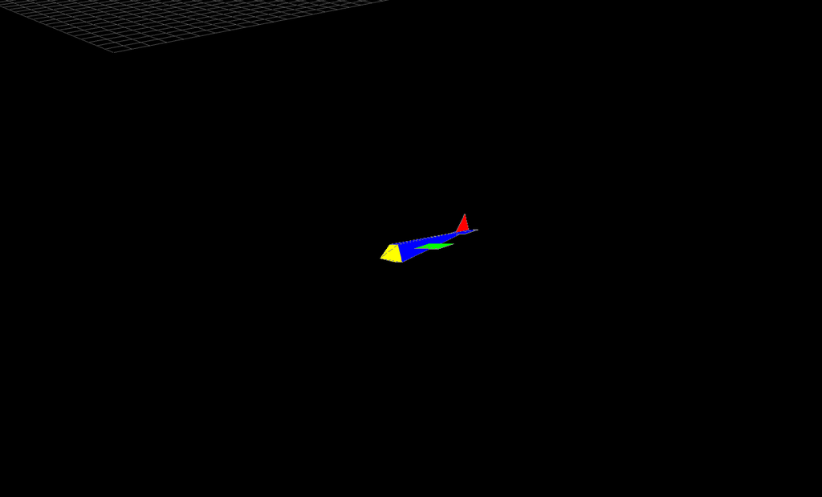

```python
# Create the trim state
Va_trim = 25.
gamma_trim = 0.
trim_state, trim_input = compute_trim(state.convert_to_numpy(), Va_trim, gamma_trim)

# Create an input signal
input_signal = Signals(amplitude=0.3,
                    duration=0.3,
                    start_time=5.0)

# Create a function for exciting the roll and spiral divergence modes
def excite_roll_spiral(sim_time: float):
    # copy the trim command
    delta_cmd = MsgDelta()
    delta_cmd.copy(trim_input)

    # Excite the roll and spiral divergence modes with aileron doublet
    delta_cmd.aileron += input_signal.doublet(sim_time)
    return delta_cmd

# Run the command
run_sim_and_display(excite_roll_spiral, trim_state)
```

## Problem 8 - Dutch roll mode

For the trim trajectory corresponding to $V_a = 25 \frac{m}{s}$ and $\gamma = 0$, use a doublet to excite the dutch roll mode.

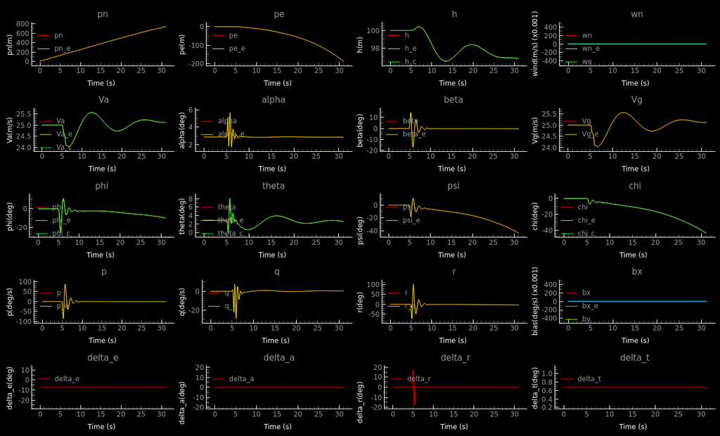

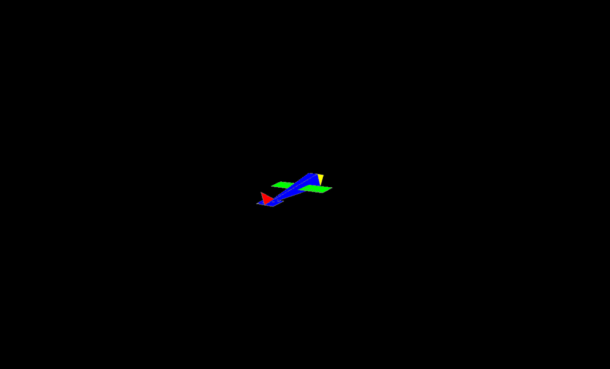

```python
# Create the trim state
Va_trim = 25.
gamma_trim = 0.
trim_state, trim_input = compute_trim(state.convert_to_numpy(), Va_trim, gamma_trim)

# Create an input signal
input_signal = Signals(amplitude=0.3,
                    duration=0.3,
                    start_time=5.0)

# Create a function for exciting the dutch roll mode
def excite_dutch_roll(sim_time: float):
    # copy the trim command
    delta_cmd = MsgDelta()
    delta_cmd.copy(trim_input)

    # Excite the dutch roll mode with rudder doublet
    delta_cmd.rudder += input_signal.doublet(sim_time)
    return delta_cmd

# Run the command
run_sim_and_display(excite_dutch_roll, trim_state)
```

## Static analysis

Run the static code analysis (you must have zero static code analysis errors to get credit). You may not modify the static code analysis configuration files.

### ISORT

Run Isort:

```
python -m isort mav_sim book_assignments
```

Terminal output (should be nothing):

### MyPy

Run MyPy

```
python -m mypy mav_sim/chap2/ mav_sim/chap3/ mav_sim/chap4/ mav_sim/chap5/ book_assignments
```

Terminal output (should indicate no error):

```
Success: no issues found in 29 source files
```

### Pylint

Run Pylint

```
python -m pylint --jobs 0 --rcfile .pylintrc mav_sim/chap2/ mav_sim/chap3/ mav_sim/chap4/ mav_sim/chap5/ book_assignments/
```

Terminal output (should indicate `10/10`)

```
Your code has been rated at 10.00/10 (previous run: 9.98/10, +0.02)
```

## Simple code checking

Note that due to the random nature of the test, you may get a warning stating

```
RuntimeWarning: invalid value encountered in sqrt
  omega_p = (-b + np.sqrt(b**2 - 4*a*c)) / (2.*a)
```

Just ignore that warning.

```python
from mav_sim.unit_tests.ch5_dynamics_test import run_auto_tests, VelocityConstraintTest, VelocityConstraintPartialTest, VariableBoundsTest, TrimObjectiveFunTest
run_auto_tests()
```

```
Starting velocity_constraint test
Passed test on velocity_constraint

Starting velocity_constraint_partial test
Passed test on velocity_constraint_partial

Starting variable_bounds test
Passed test on variable_bounds

Starting trim_objective_fun test


Failed test!
test:
 Inputs:x:
[[  72.47826359]
 [  23.29752196]
 [  61.10417341]
 [ 167.43767023]
 [ 146.26395145]
 [   2.74058483]
 [ 114.77449101]
 [  20.42161106]
 [-117.50784744]
 [-190.83127839]
 [ 287.57429167]
 [  16.49020737]
 [-104.08581692]
 [ -61.81240809]
 [-169.77416568]
 [  50.72701236]]
Va: 35.339030665481175
gamma: 1.262798238283002
R: 461.1176337415098
psi_weight: -2209409.8332912456
Output
out: -1.1261537617061194e+17
actual out:  -1.1261537617061197e+17
```

[output not shown]

[output not shown]